# Boas práticas em análises de séries temporais em herpetologia

## Asymmetric Eigenvectors Maps - AEM

```r
time1 <- c(1, 2, 3, 4, 5, 6, 7, 8)
time2 <- c(10, 1, 9, 0, 0, 5, 0, 0)
time3 <- c(9, 11, 1, 2, 3, 7, 8, 9)
time4 <- c(6, 14, 5, 11, 5, 3, 5, 8)
time5 <- c(2, 8, 4, 15, 3, 0, 15,4)
time6 <- c(7, 14, 16, 1, 20, 11, 7, 4)
time7<- c(4, 1, 2, 15, 1, 20, 1, 10)
time8 <- c(0, 1, 6, 16, 1, 10, 2, 1)
time9 <- c(0, 1, 6, 16, 1, 10, 2, 1)
time10 <- c(8, 7, 6, 5, 1,3, 2, 1)
time11 <- c(0, 1, 6, 16, 1, 10, 2, 1)
time12 <- c(6, 0, 6, 16, 1, 0, 2, 1)
time13 <- c(5, 1, 7, 16, 1, 10, 2, 1)
time14 <- c(4, 1, 0, 8, 1, 9, 2, 1)
time15 <- c(3, 0, 6, 16, 1, 10,12, 1)
time16 <- c(2, 1, 6, 16, 1, 10, 2, 0)
time17 <- c(1, 1, 6, 16, 1, 10, 2, 1)
time18 <- c(9, 11, 1, 2, 3, 7, 8, 9)
time19 <- c(10, 1, 9, 0, 0, 5, 0, 0)
time20 <- c(1, 2, 3, 4, 5, 6, 7, 8)
arbor <- rbind(time1, time2, time3, time4, time5, time6, time7, time8, time9, time10, time11, time12, time13, time14, time15, time16, time17, time18, time19, time20)
```

```r
dates <- as.Date(c(1,2,3,4,5,6,7,8,9,10,11,12,13,14,15,16,17,18,19,20),origin="2000/1/1")
autocor.limit <- 522
```

Construindo um vetor de pesos para as arestas, cada um representando a facilidade de troca entre datas adjacentes (nós).

```r
weights <- weight.time(dates, alpha=2, max.d = 522)
```

[figure not shown]

Calculando os vetores AEM (20 é o número de amostras)

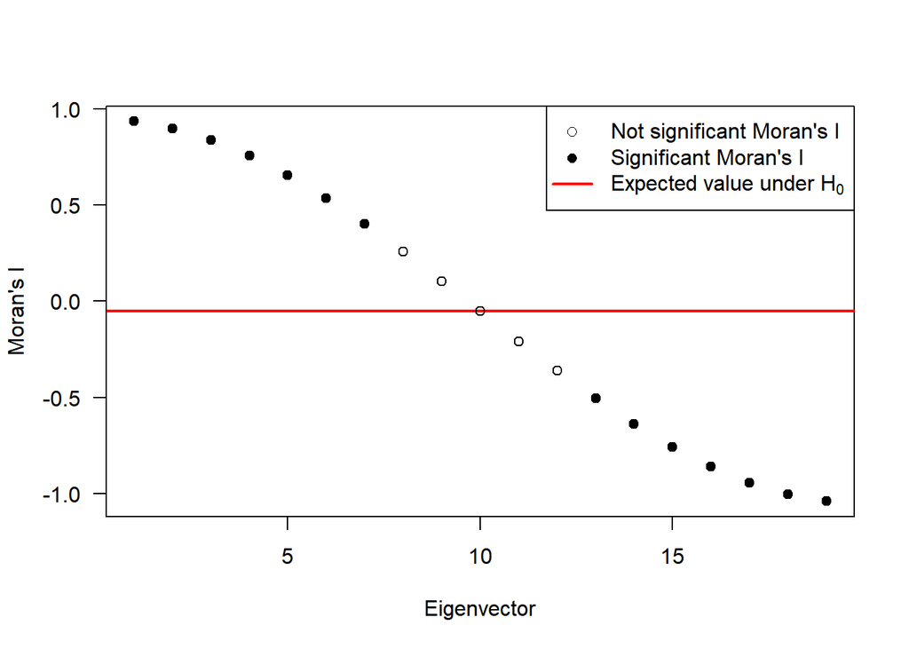

```r
aem.40.out <- aem.time(20, w=weights, moran=TRUE, plot.moran=TRUE)
```

```r
aem.40.out$Moran
```

```
##          Moran p.value Positive
## 1   0.93505676   0.001     TRUE
## 2   0.89842494   0.001     TRUE
## 3   0.83837495   0.001     TRUE
## 4   0.75638542   0.001     TRUE
## 5   0.65447520   0.001     TRUE
## 6   0.53515367   0.006     TRUE
## 7   0.40135892   0.023     TRUE
## 8   0.25638542   0.074     TRUE
## 9   0.10380289   0.232     TRUE
## 10 -0.05263158   0.509    FALSE
## 11 -0.20906604   0.247    FALSE
## 12 -0.36164857   0.074    FALSE
## 13 -0.50662208   0.017    FALSE
## 14 -0.64041683   0.007    FALSE
## 15 -0.75973836   0.001    FALSE
## 16 -0.86164857   0.001    FALSE
## 17 -0.94363810   0.001    FALSE
## 18 -1.00368810   0.001    FALSE
## 19 -1.04031992   0.001    FALSE
```

19 vetores foram criados a partir dos dados:

- 9 AEM modelando uma correlação temporal positiva
- 10 AEM modelando uma correlação temporal negativa

Calculando a análise de redundância (RDA) das espécies pela matriz de auto-vetores AEM modelando a correlação temporal positiva

```r
fauna.aem.40.pos <- rda(arbor, aem.40.out$aem[, aem.40.out$Moran$Positive])
anova(fauna.aem.40.pos)
```

```
## Permutation test for rda under reduced model
## Permutation: free
## Number of permutations: 999
##
## Model: rda(X = arbor, Y = aem.40.out$aem[, aem.40.out$Moran$Positive])
##          Df Variance      F Pr(>F)
## Model     9   83.596 1.1701  0.323
## Residual 10   79.383
```

```r
RsquareAdj(fauna.aem.40.pos)
```

```
## $r.squared
## [1] 0.5129222
##
## $adj.r.squared
## [1] 0.07455223
```

Modelando a correlação temporal negativa

```r
fauna.aem.40.neg <- rda(arbor, aem.40.out$aem[, !aem.40.out$Moran$Positive])
anova(fauna.aem.40.neg)
```

```
## Permutation test for rda under reduced model
## Permutation: free
## Number of permutations: 999
##
## Model: rda(X = arbor, Y = aem.40.out$aem[, !aem.40.out$Moran$Positive])
##          Df Variance      F Pr(>F)
## Model    10   79.383 0.8547   0.69
## Residual  9   83.596
```

```r
RsquareAdj(fauna.aem.40.neg)
```

```
## $r.squared
## [1] 0.4870778
##
## $adj.r.squared
## [1] -0.08283582
```

Selecionado os AEM que entrarão na modelagem

```r
sel.aem.40 <- forward.sel(arbor, aem.40.out$aem, nperm=9999, alpha=0.10)
```

```
## Testing variable 1
## Testing variable 2
## Testing variable 3
## Testing variable 4
## Testing variable 5
## Procedure stopped (alpha criteria): pvalue for variable 5 is 0.189500 (> 0.100000)
```

```r
sel.aem.40
```

```
##   variables order         R2     R2Cum  AdjR2Cum        F pvalue
## 1        V2     2 0.15508258 0.1550826 0.1081427 3.303857 0.0129
## 2       V10    10 0.10798941 0.2630720 0.1763746 2.491179 0.0201
## 3       V19    19 0.07573584 0.3388078 0.2148343 1.832710 0.0941
## 4        V4     4 0.07164281 0.4104506 0.2532375 1.822820 0.0955
```

Não inclua as variáveis selecionadas com valores de *p* muito maiores que 0.05

```r
aem.select <- sort(sel.aem.40$order[sel.aem.40$pval<=0.08])
aem.select.pos <- c(2,4)
aem.select.neg <- c(10,19)
```

Verificar em `aem.40.out$Moran` quais foram positivos e negativos

Plote os AEMs selecionados:

```r
par(mfrow=c(3,3))
```

os positivos

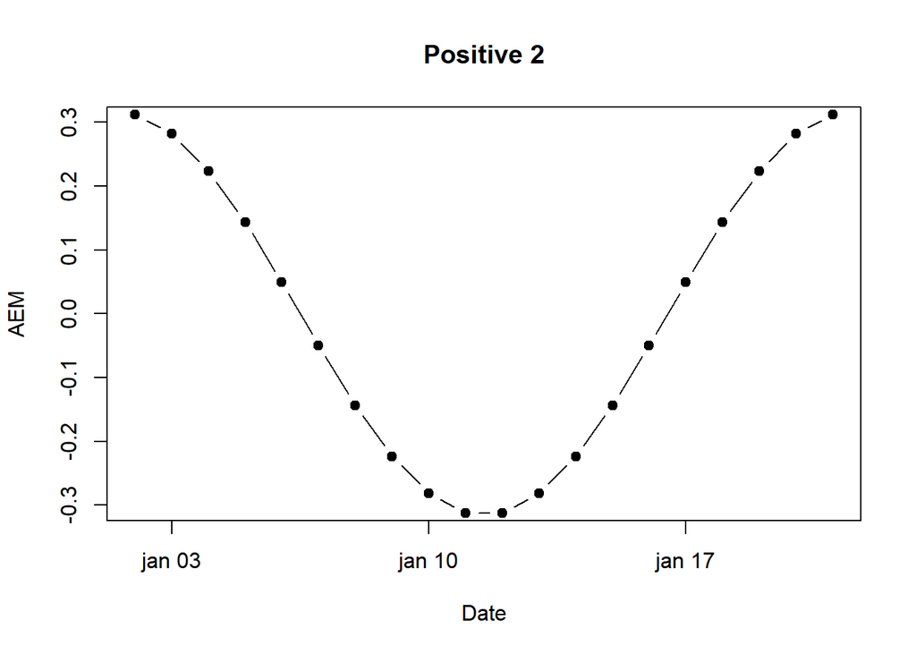

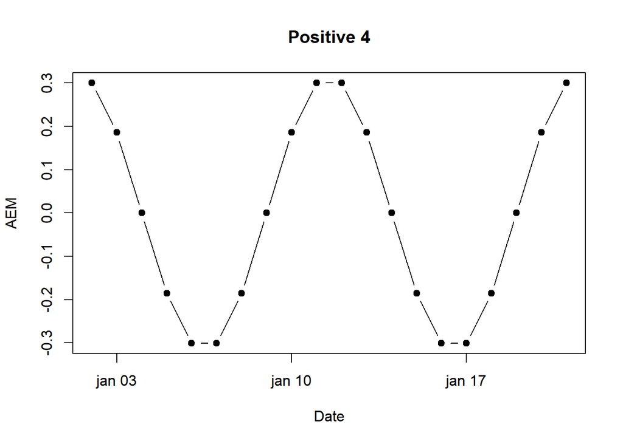

```r
for(i in 1:2) { # 2 é o número de variáveis selecionadas
  plot(dates, aem.40.out$aem[,aem.select.pos[i]], type="b", pch=19, main = paste("Positive", aem.select.pos[i]), xlab="Date", ylab="AEM", ylim=c(-0.3,0.3))
}
```

e os negativos

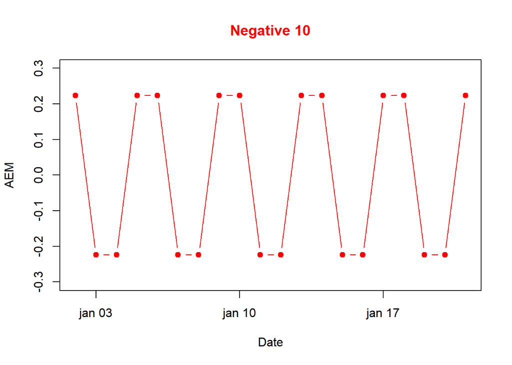

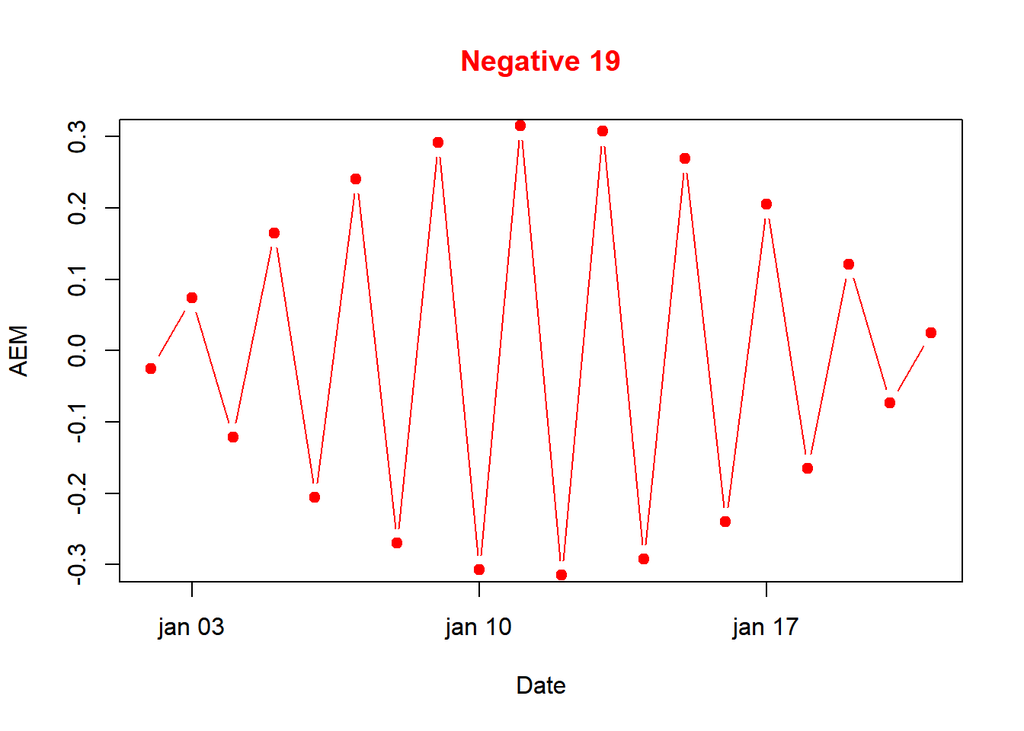

```r
for(i in 1:2) {
  plot(dates, aem.40.out$aem[,aem.select.neg[i]], type="b", pch=19, main =
         paste("Negative", aem.select.neg[i]), xlab="Date", ylab="AEM", col="red", col.main="red", ylim=c(-0.3,0.3))
}
```

```r
par(mfrow=c(1,1))
```

```r
fauna.aem.40.pos.5 <- rda(arbor~ ., as.data.frame(aem.40.out$aem[,aem.select.pos]))
anova(fauna.aem.40.pos.5, by="axis")
```

```
## Permutation test for rda under reduced model
## Forward tests for axes
## Permutation: free
## Number of permutations: 999
##
## Model: rda(formula = arbor ~ V1 + V2, data = as.data.frame(aem.40.out$aem[, aem.select.pos]))
##          Df Variance      F Pr(>F)
## RDA1      1   27.570 3.7190  0.025 *
## RDA2      1    9.381 1.2654  0.266
## Residual 17  126.027
## ---
## Signif. codes:  0 '***' 0.001 '**' 0.01 '*' 0.05 '.' 0.1 ' ' 1
```

```r
RsquareAdj(fauna.aem.40.pos.5)
```

```
## $r.squared
## [1] 0.2267254
##
## $adj.r.squared
## [1] 0.1357519
```

```r
fauna.aem.40.neg.4 <- rda(arbor~ ., as.data.frame(aem.40.out$aem[,aem.select.neg]))
anova(fauna.aem.40.neg.4, by="axis")
```

```
## Permutation test for rda under reduced model
## Forward tests for axes
## Permutation: free
## Number of permutations: 999
##
## Model: rda(formula = arbor ~ V1 + V2, data = as.data.frame(aem.40.out$aem[, aem.select.neg]))
##          Df Variance      F Pr(>F)
## RDA1      1   24.744 3.1620  0.047 *
## RDA2      1    5.199 0.6644  0.668
## Residual 17  133.036
## ---
## Signif. codes:  0 '***' 0.001 '**' 0.01 '*' 0.05 '.' 0.1 ' ' 1
```

```r
RsquareAdj(fauna.aem.40.neg.4)
```

```
## $r.squared
## [1] 0.1837252
##
## $adj.r.squared
## [1] 0.08769292
```

Visualizar os eixos da RDA dos modelos significativos de AEM produzidos pelo AEM selecionado

```r
par(mfrow=c(3,1))
```

os positivos

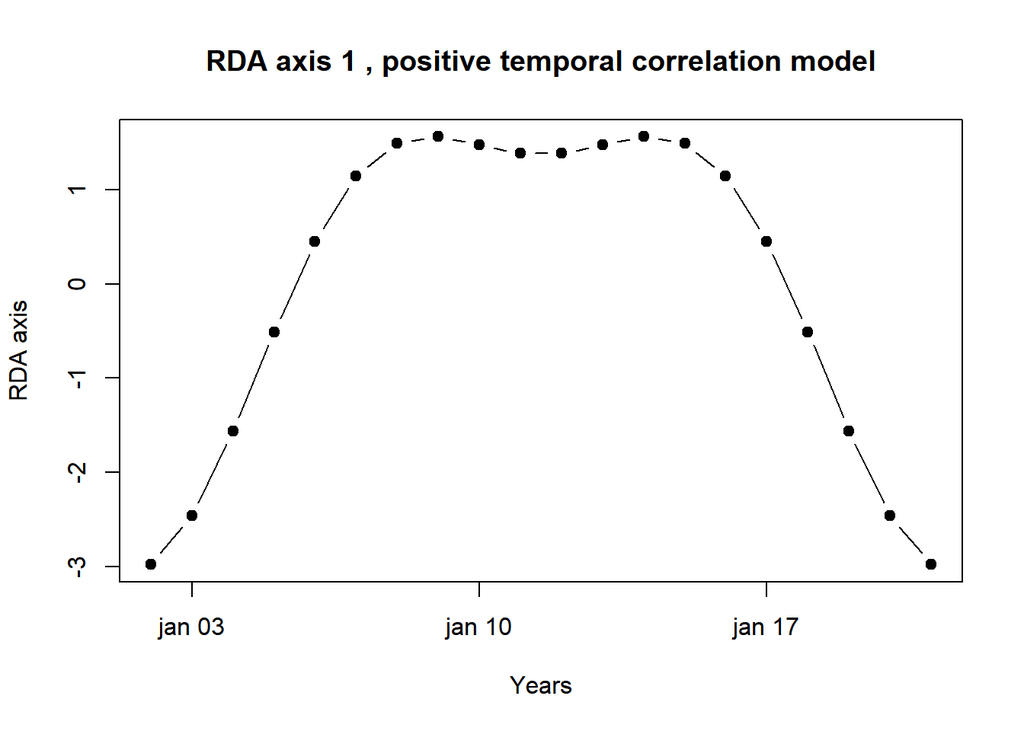

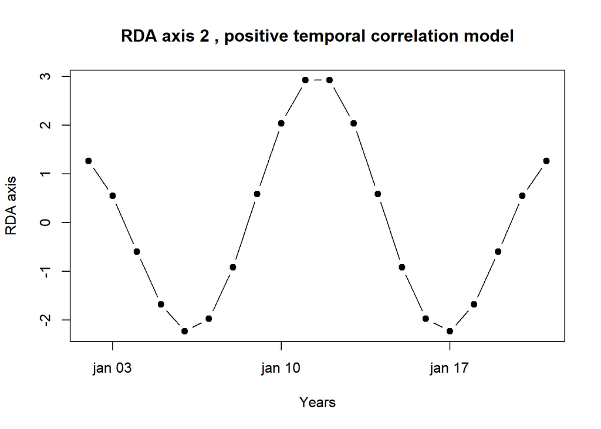

```r
for(i in 1:2) {
  plot(dates, scores(fauna.aem.40.pos.5, display="lc", choices=i), type="b", pch=19, main
       = paste("RDA axis", i, ", positive temporal correlation model"), xlab="Years", ylab="RDA axis")
}
```

e o único negativo

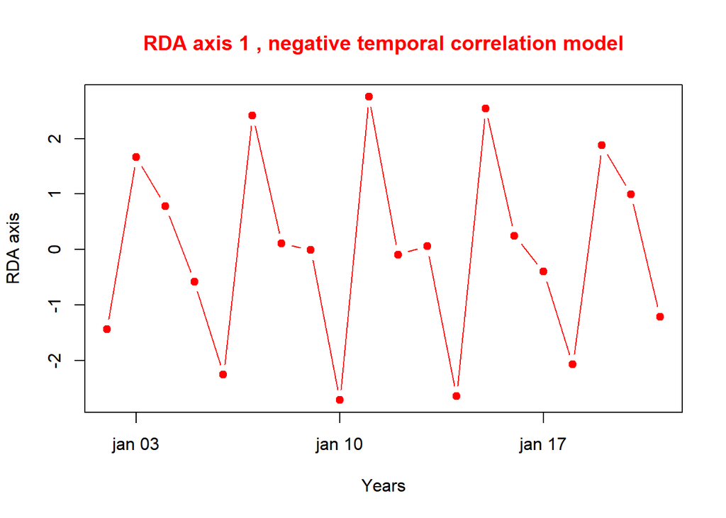

```r
plot(dates, scores(fauna.aem.40.neg.4, display="lc", choices=1), type="b", pch=19, main
     = paste("RDA axis", 1, ", negative temporal correlation model"), xlab="Years", ylab="RDA axis", col="red", col.main="red")
```

```r
par(mfrow=c(1,1))
```